# Лабораторная работа №8

TikZ — diagrams and drawings as code

Усман Траоре

Российский университет дружбы народов, Москва, Россия

05 декабря 2025

# Цель работы

## Основная цель

Освоение базовых возможностей **TikZ** для создания графических объектов в LaTeX:

- построение линий и фигур,
- работа со стилями и цветами,
- использование узлов (nodes),
- построение простых графов,
- анализ процесса компиляции TikZ-документов.

## Компиляция tikz-1.tex

- документ успешно собран через `pdflatex`,
- автоматически подключены пакеты `tikz` и `pgf`,
- ошибок компиляции не возникло.

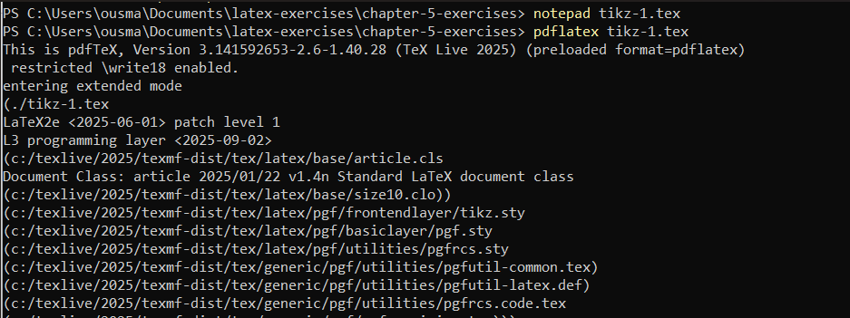

Компиляция tikz-1.tex

## Результат работы

- построены простые линии,
- использованы прямые соединения координат,
- фигуры отображены корректно.

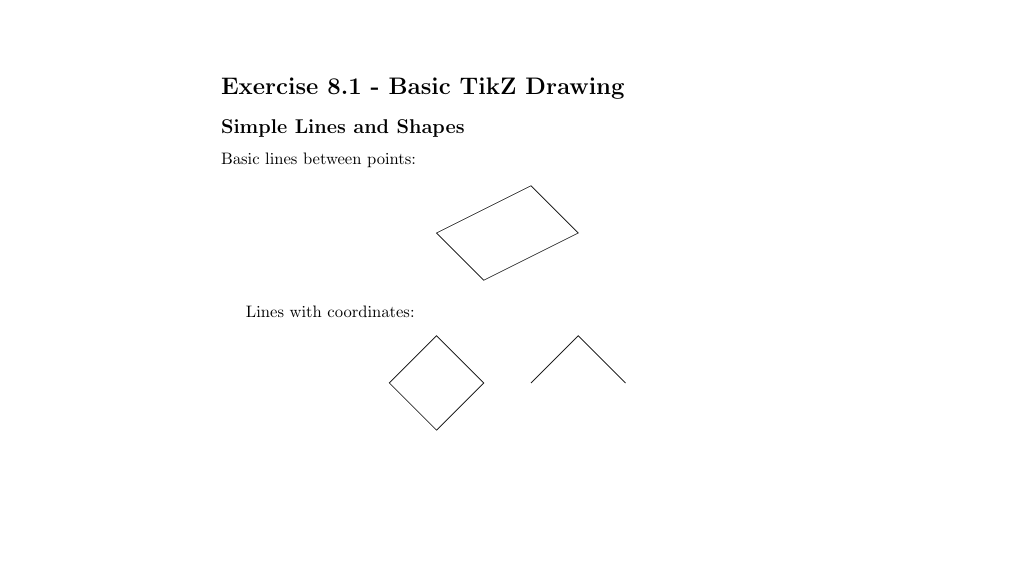

Exercise 8.1

## Компиляция tikz-2.tex

- загружены модули TikZ,
- корректно обработаны стили линий и цвета,
- PDF сформирован без ошибок.

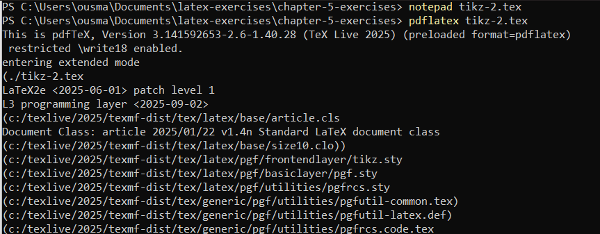

Компиляция tikz-2.tex

## Результат работы

- отображены стрелки, цветные линии, пунктиры,
- построены простые геометрические фигуры.

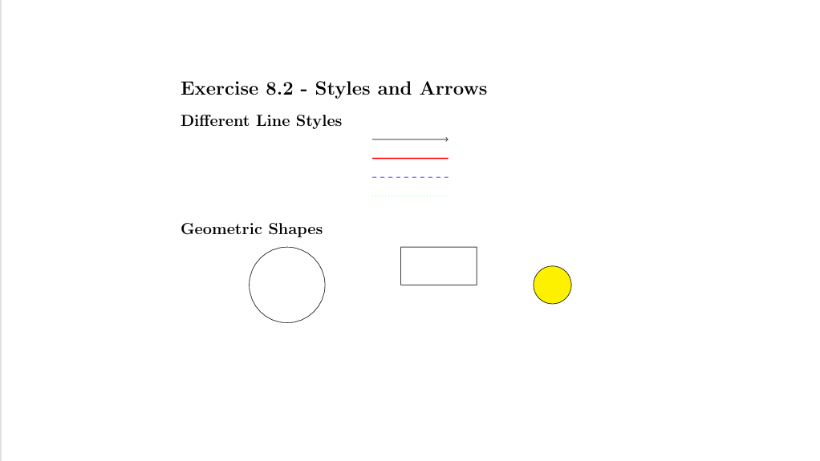

Exercise 8.2

## Компиляция tikz-3.tex

- успешно подключены шрифты и внутренние библиотеки TikZ,
- компилятор корректно обработал текстовые и математические узлы.

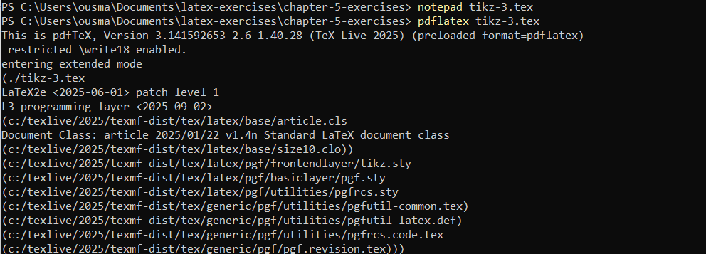

Компиляция tikz-3.tex

## Результат работы

- отображены текстовые узлы,
- узлы с окружностями и прямоугольниками,
- математические выражения внутри фигур.

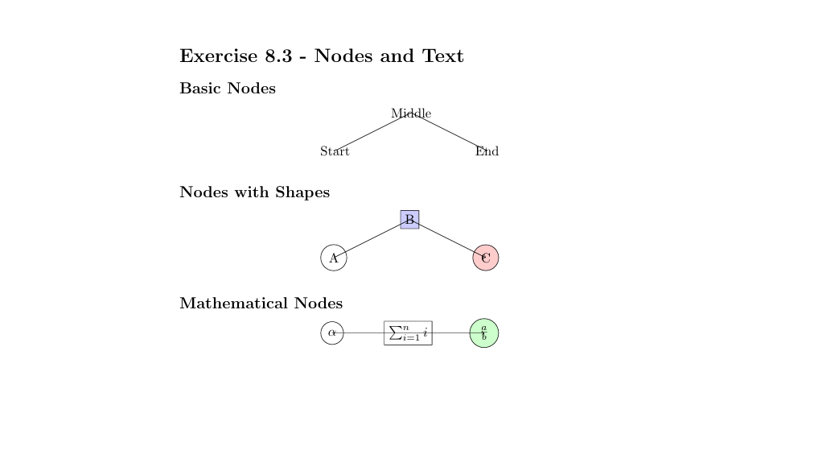

Exercise 8.3

## Компиляция tikz-4.tex

- все модули TikZ успешно загружены,
- PDF создан без предупреждений.

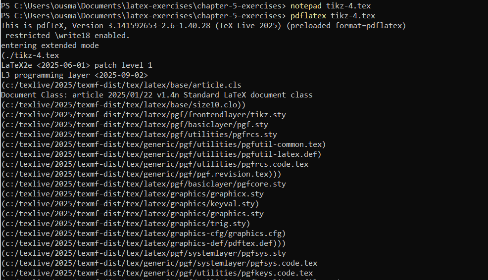

Компиляция tikz-4.tex

## Результат работы

- построен граф с вершинами A–E,
- рёбра имеют подписи,
- выполнен пример с разными типами линий.

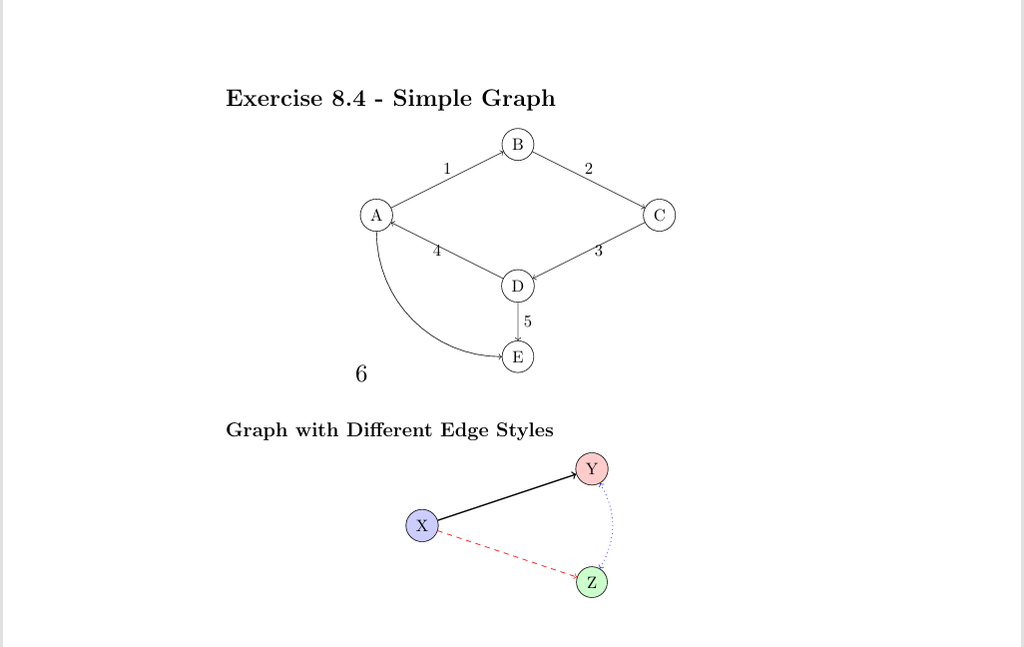

Exercise 8.4

## Общие выводы по компиляции

- все `.tex` файлы успешно обработаны `pdflatex`,
- отсутствуют ошибки и критические предупреждения,
- TikZ корректно функционирует в конфигурации TeX Live,
- все изображения соответствуют ожидаемым результатам упражнений.

# Итоги работы

## Вывод

В ходе выполнения лабораторной работы были освоены:

- основы языка построения графики **TikZ**,
- линии, кривые, стили, цвета и стрелки,
- создание и оформление узлов,
- построение простых графов,
- анализ и диагностика компиляции TikZ-документов.

Работа подтверждает корректную установку TikZ и TeX Live, а также успешное применение инструментов для построения графики в LaTeX.